# sparkTable: Generating Graphical Tables for Websites and Documents with R

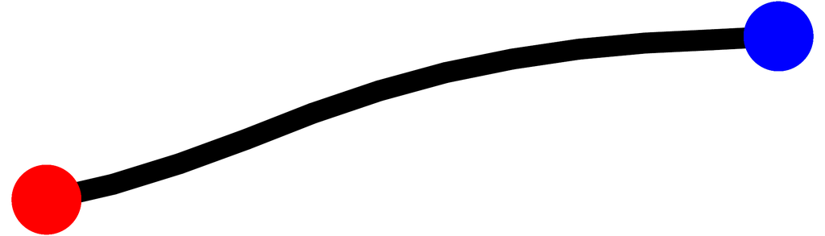

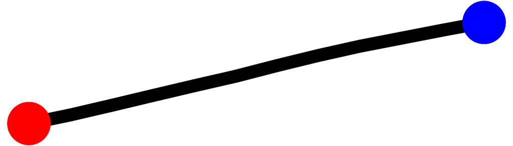

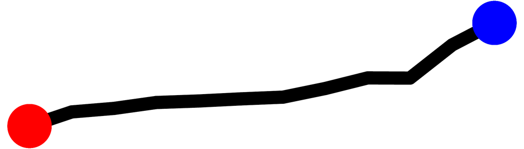

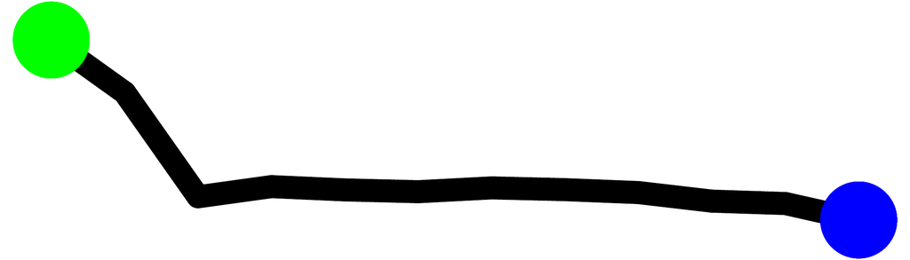

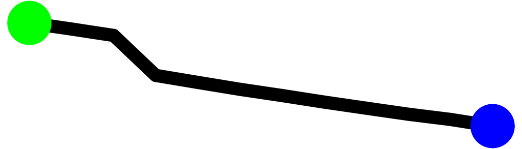

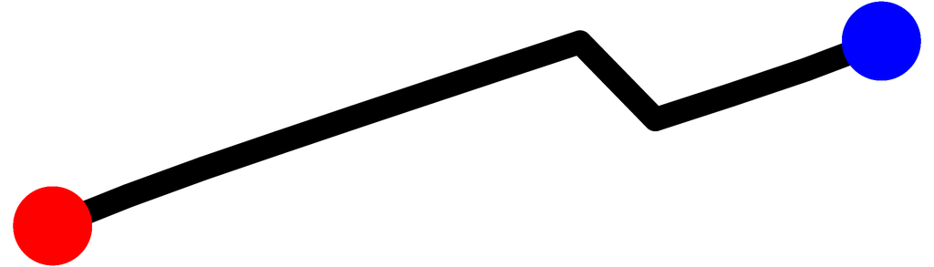

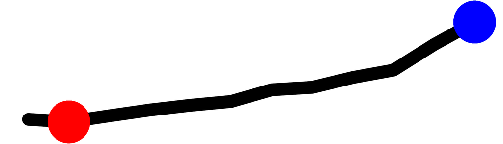

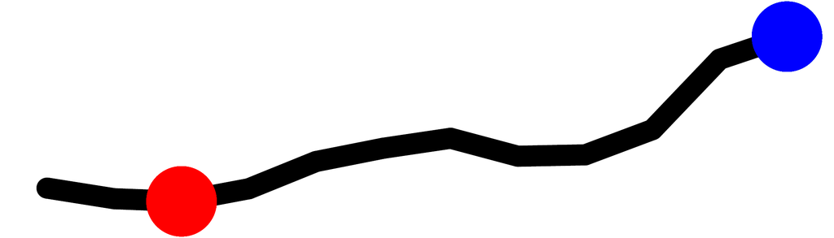

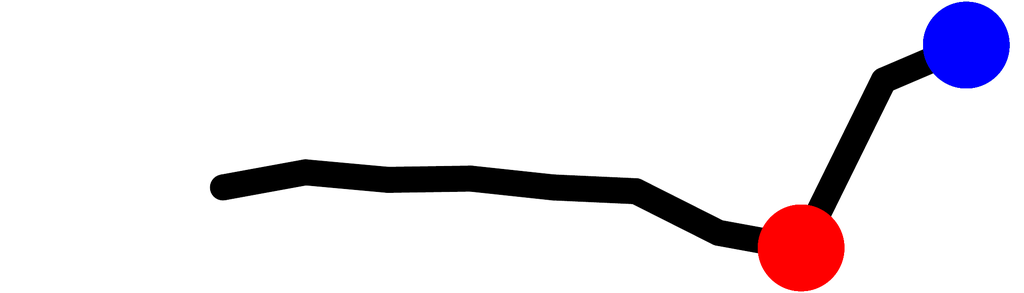

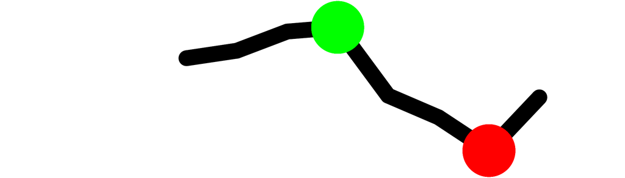

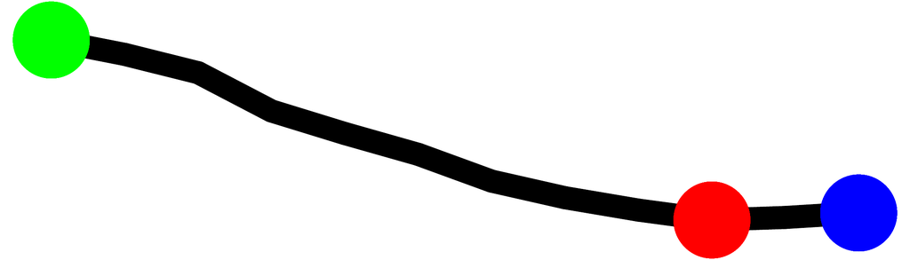

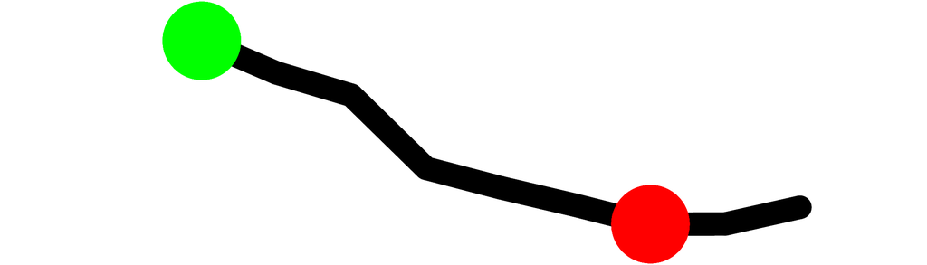

**ES**

**IT**

**MT**

**GR**

**CY**

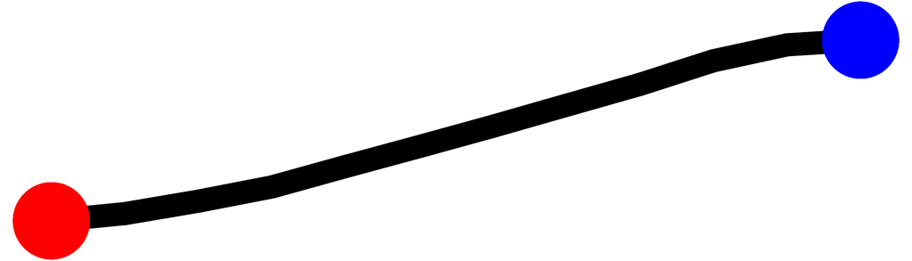

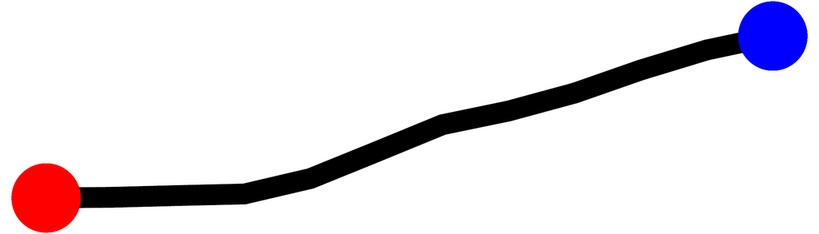

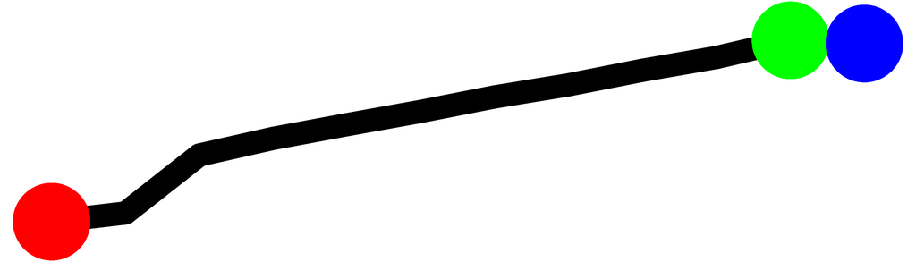

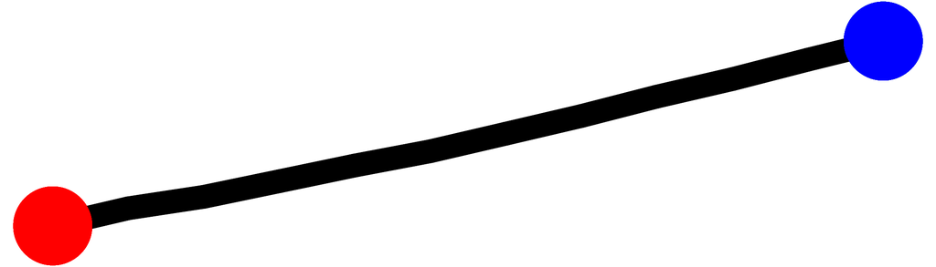

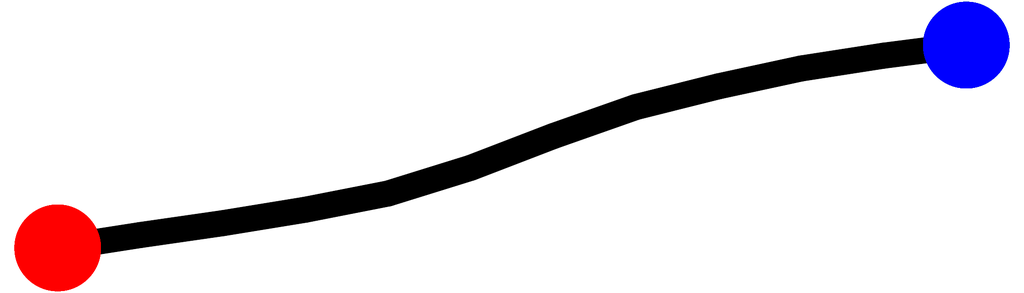

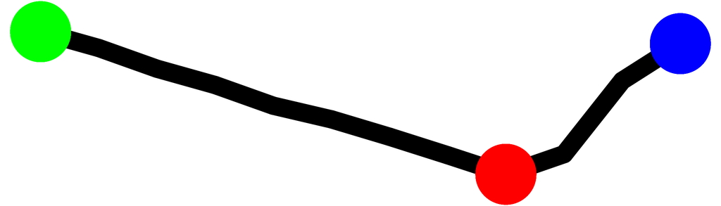

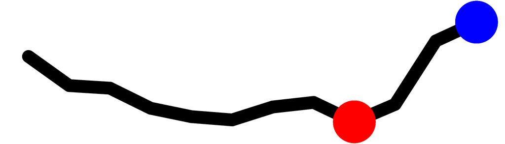

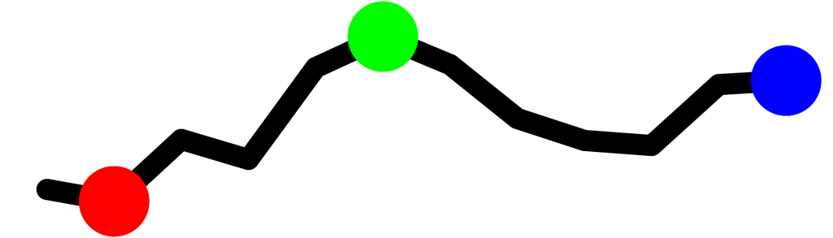

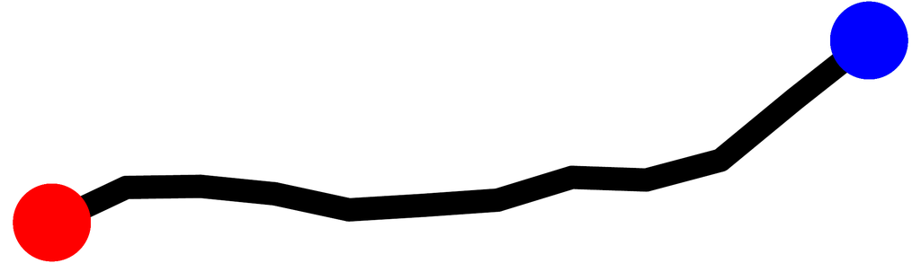

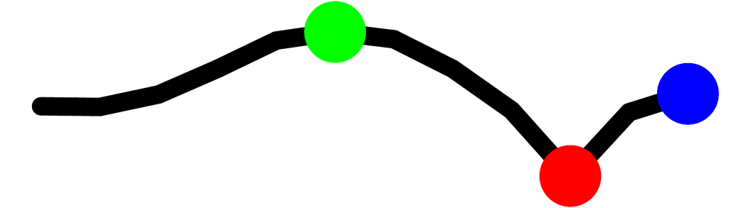

# Interactive features

Until recently *sparkTable* only provided rigid views of graphical tables in documents and on homepages. However, when including a graphical table on a homepage some interactivity is beneficial. Two functions using the functionality from [*shiny*](https://CRAN.R-project.org/package=shiny) (RStudio and Inc. 2014) allow for interactive graphical tables.

#### View your graphical table in a shiny app:

`showSparkTable()` is a function to generate a shiny app to view your graphical table directly in a browser with some basic interactive functions like sorting and filtering. At the moment, methods for objects of class ‘`sparkTable`’ and ‘`data.frame`’ already are implemented. Figure 1 shows the output of the function applied to a ‘`sparkTable`’ object.

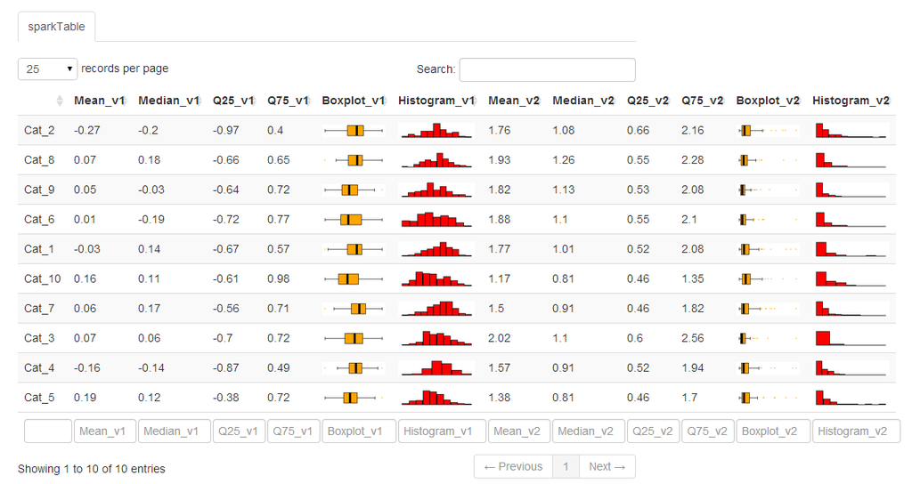

Figure 1: Shiny output of a ‘`sparkTable`’ object.

In the following, the key features of `customizeSparkTable()` are discussed.

## Tab 1: Import *sparkTable* objects

The provided app is organized in tabs. In each of the five tabs, specific changes can be made. Figure 2 shows the first tab – *importData* – that is available to the user when the function is called for the first time. We point out that this function has to be started with a ‘`sparkTable`’ object as input.

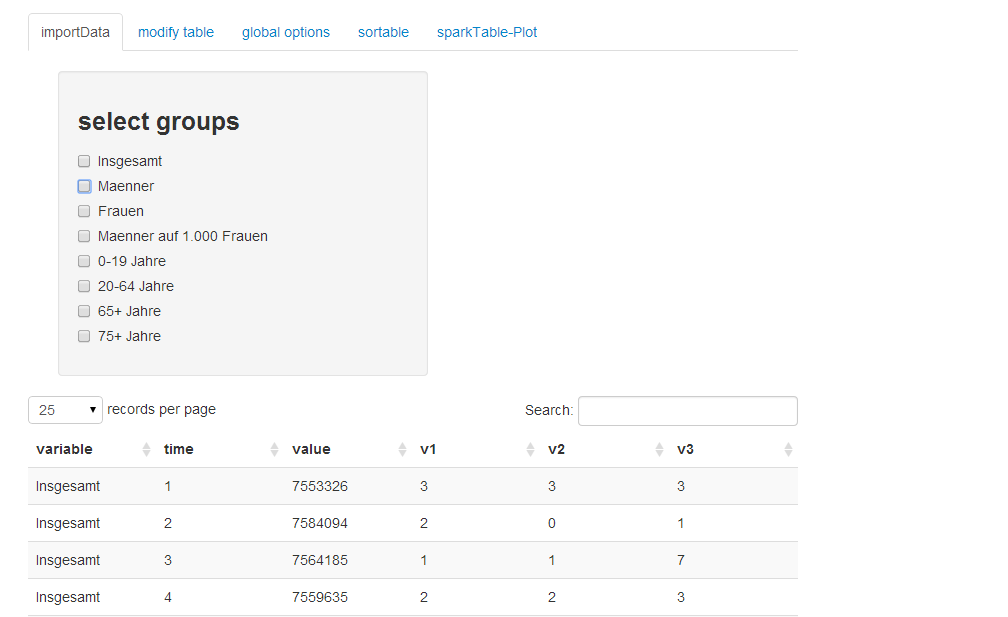

Figure 2: Data options applicable for a ‘`sparkTable`’ object.

In the upper part of this page, all possible groups that are available in the input data object are listed. In the lower part of the page an interactive table is shown. By using the mouse to toggle check-boxes it is possible to choose the groups that should be included in the final output.

## Tab 2: Preparation of the table

The second tab – *modify table* – that is shown in Figure 3 is also partitioned into two parts.

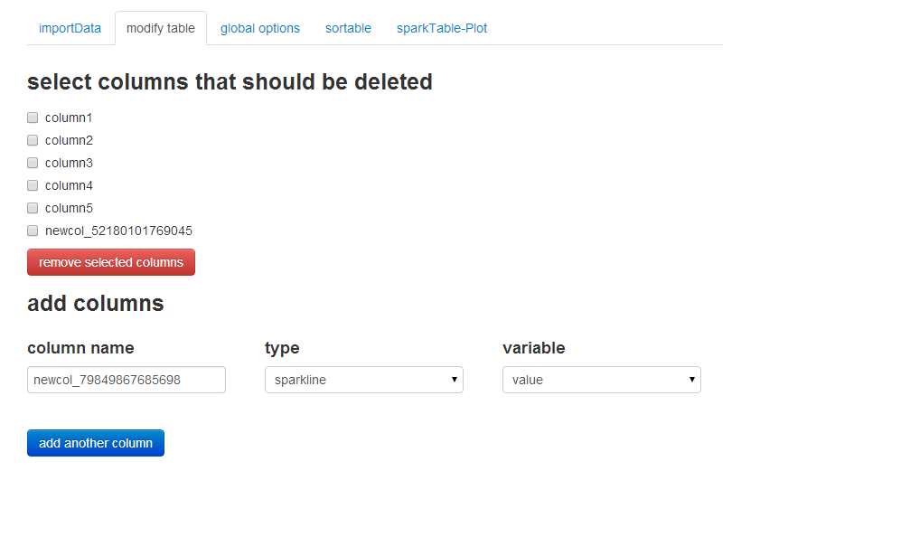

Figure 3: Possibilities for modifications of the loaded ‘`sparkTable`’ object.

In the upper part, all the columns that are currently present in the output table are listed. It is then possible to select columns that should be deleted. After selecting the corresponding columns by toggling the check boxes and clicking on the *remove selected columns*-button, these columns are dropped from the table. However, in this tab it is also possible to add an additional column to the table. In this case the user needs to provide a column name and can select both the type of the column and the variable, which should be used, by selecting values from a drop-down menu. All supported types of graphs (*sparkline*, *sparkbar*, *sparkhist* and *sparkbox*) are available as well as the special type *function*, which can be used to calculate some statistics of the selected variable. An example is the determination of the maximal data value.

## Tab 3: Global options

In the *global options*-tab (see Figure 4) it is possible to change the specifics of the current output.

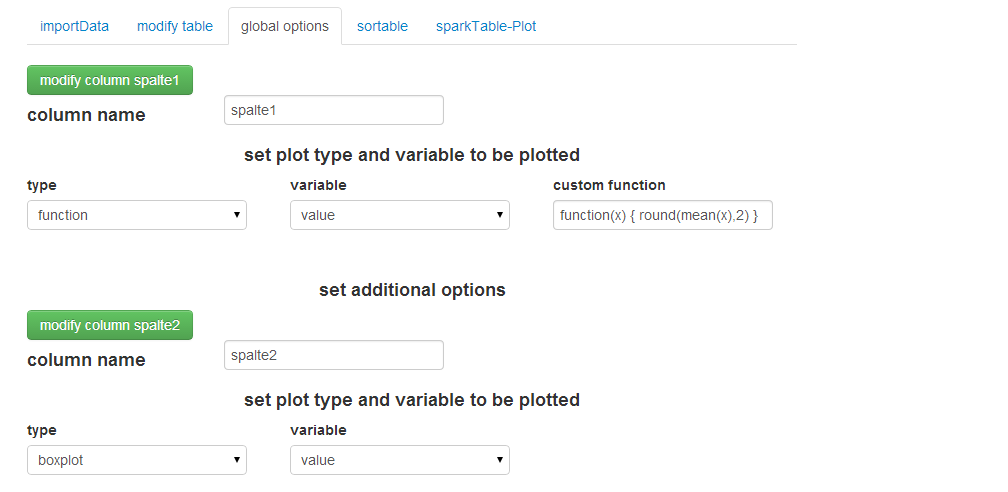

Figure 4: Global options.

For each column, a block of options is listed. The user has the option to change the column name by modifying the current heading in a text box. It is also possible to change the type of a column by selecting a new type from a drop-down box or to adjust graphical parameters (such as point sizes or line width or colors) for some plots. For columns that are of type *function*, the function definition can be altered. For the adjustment of graphical parameters, suitable inputs such as sliders or drop-down boxes are used. After the desired modification has been applied, the user is required to press the modify-button for the currently changed column. The page will refresh and additional changes can be made. We note, however, that for the time being it is only possible to change one variable after another.

## Tab 4: Ordering of columns

In the fourth tab (*sortable*), which is shown in Figure 5, it is possible to interactively change the ordering of columns (in the first part of the page) and rows (in the second part of the page) by using the mouse to drag boxes around until the desired ordering has been reached.

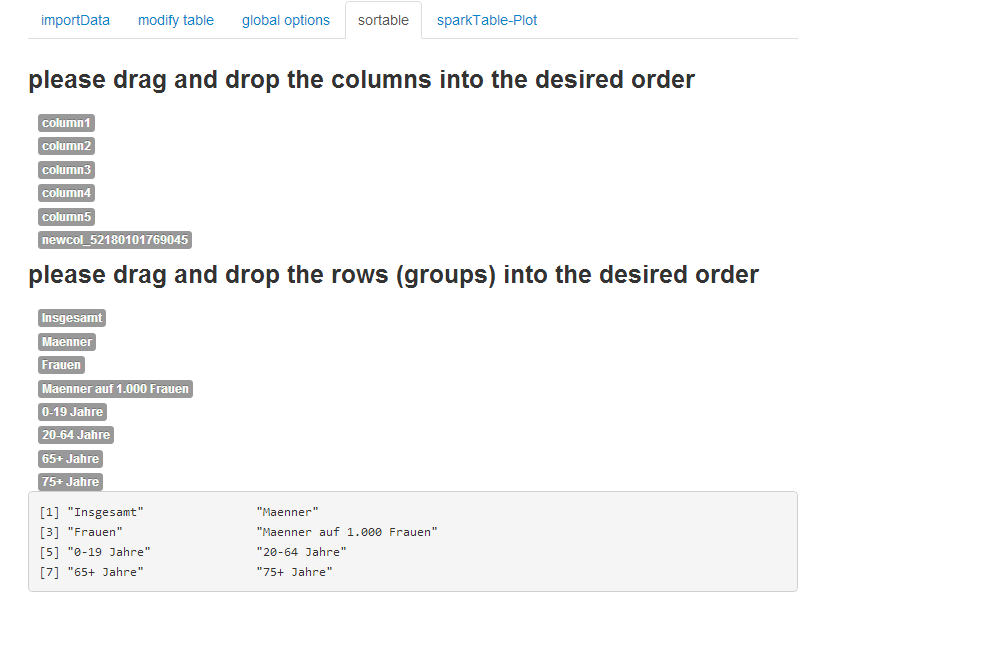

Figure 5: Sort variables and groups in the sparkTable.

The current result is automatically applied to the ‘`sparkTable`’ object, which is always visible in the last tab.

## Tab 5: The graphical table

In the tab *sparkTable-Plot* (see Figure 6), the current graphical table with all the current options is displayed. At the bottom of the page the user is offered two buttons. Using *Export to html*, the graphical table can be exported as an HTML-file, whereas pressing the *Export to latex*-button exports the final output into tex-format. Furthermore, the required R code to create the current graphical table is also printed to the current R session. Thus, users may adjust, copy or reuse a suitable plot-layout that was created with the interactive procedure.

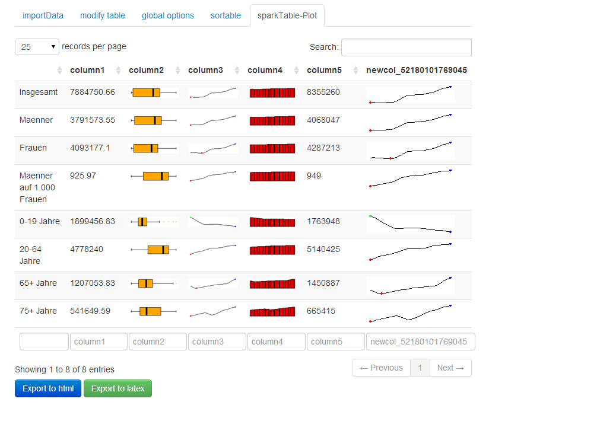

Figure 6: Preview of the output sparkTable.

# Conclusions

Eduard R. Tufte’s quote “Graphical excellence is that which gives to the viewer the greatest number of ideas in the shortest time with the least ink in the smallest space” holds especially true for graphical tables embedding sparkgraphs, since a lot of information can be put into a table with small but comprehensive (spark) graphs.

Histograms and box-plots presented in graphical tables can be used to show the distribution of data together with some basic statistics in any publication that present empirical results or analyses in general. Sparkbars can thereby also be used to visualize frequency counts on categories of a variable. For specific summaries of data using sparkboxplots and sparkbars, see for example Hron, Templ, and Filzmoser (2013). Also tabulated information for policy needs can be embedded in graphical tables.

The package *sparkTable* provides a flexible and interactive way to produce graphical tables for printed or web publication. Graphical tables have the key advantage to provide more information and insight in the same amount of space. A strict class oriented implementation using S4 classes organizes the internal production of graphical tables and sparklines in a pre-defined manner. The users are provided with highly customizable functions to create sparklines and tables in a flexible manner. The sparklines can be modified easily and the tables can also contain arbitrarily comples statistics based on the underlying data.

Additionally, interactivity is added with the help of the package *shiny*. Especially these interactive features allow non-experts in R to create graphical tables enriched by all kind of sparklines. Tables can then be exported to HTML or LaTeX and additionally the code required for various plots is shown both when the interactive shiny-app is used and when graphical tables are exported with `export()`.

Cleveland, W. S., and R. McGill. 1987. “Graphical Perception: The Visual Decoding of Quantitative Information on Graphical Displays of Data.” *Journal of the Royal Statistical Society. Series A (General)* 150 (3): 192–229.

Dahl, David B. 2014. *Xtable: Export Tables to LaTeX or HTML*. http://CRAN.R-project.org/package=xtable.

Friendly, M. 2008. “A Brief History of Data Visualization.” In *Handbook of Data Visualization*, edited by C. Chen, W. Härdle, and A Unwin, 15–56. Heidelberg: Springer-Verlag.

Heer, J., and M. Agrawala. 2006. “Multi-Scale Banking to 45 Degrees.” *IEEE Transactions on Visualization and Computer Graphics* 12 (5): 701–8.

Hill, E. 2011. “JMP© 9 Add-Ins: Taking Visualization of SAS© Data to New Heights.” In *SAS Global Forum 2011*.

Horner, J. 2011. *Brew: Templating Framework for Report Generation*. http://CRAN.R-project.org/package=brew.

Hron, K., M. Templ, and P. Filzmoser. 2013. “Estimation of a Proportion in Survey Sampling Using the Logratio Approach.” *Metrika* 76 (6): 799–818.

Inbar, O., N. Tractinsky, and J. Meyer. 2007. “Minimalism in Information Visualization: Attitudes Towards Maximizing the Data-Ink Ratio.” In *Proceedings of the 14th European Conference on Cognitive Ergonomics: Invent! Explore!*, 185–88. ECCE ’07. New York, NY, USA.

Kowarik, A., B. Meindl, and M. Templ. 2015. *sparkTable: Sparklines and Graphical Tables for TeX and HTML*. http://CRAN.R-project.org/package=sparkTable.

Miller, J. E. 2004. *The Chicago Guide to Writing about Numbers*. Chicago Guides to Writing, Editing, And. University of Chicago Press.

RStudio, and Inc. 2014. *Shiny: Web Application Framework for R*. http://CRAN.R-project.org/package=shiny.

Templ, Matthias, Beat Hulliger, Alexander Kowarik, and Karin Fürst. 2013. “Combining Geographical Information and Traditional Plots: The Checkerplot.” *International Journal of Geographical Information Science* 27 (4): 685–98.

The United Nations Economic Commission for Europe. 2009. *Making Data Meaningful. Part 2: A Guide to Presenting Statistics*.

Tufte, E. R. 1990. *Envisioning Information*. Graphics Press.

Tufte, Edward R. 1986. *The Visual Display of Quantitative Information*. Cheshire, CT, USA: Graphics Press.

———. 2001. *The Visual Display of Quantitative Information*. 2nd ed. Hardcover; Bertrams.

Wickham, H. 2013. “Statistical Graphics.” *Encyclopedia of Environmetrics*.

Xie, Yihui. 2014. *Knitr: A General-Purpose Package for Dynamic Report Generation in R*. http://CRAN.R-project.org/package=knitr.

Zeileis, A., K. Hornik, and P. Murrell. 2009. “Escaping RGBland: Selecting Colors for Statistical Graphics.” *Computational Statistics & Data Analysis* 53 (9): 3259–70.